# Lavoro di Gruppo 2 - Analisi di dati ERP (versione finale)

# 1 Dataset

Questo lavoro di gruppo richiede di effettuare l’analisi di un dataset ERP (*Event-Related Potential*), ossia un insieme di dati raccolti durante esperimenti di elettroencefalografia (EEG), usati per analizzare le risposte elettriche del cervello a stimoli specifici.

Il dataset originale è parte di ERPcore (una risorsa online liberamente disponibile che consiste in paradigmi ottimizzati, script di controllo dell’esperimento, dati di esempio di 40 partecipanti, pipeline di elaborazione dei dati e script di analisi) e consiste in un esperimento con 40 partecipanti esposti alla visione passiva di quattro tipologie di stimoli:

- Volti
- Volti scrambled (ossia manipolati per alterare la disposizione delle caratteristiche facciali)
- Automobili
- Automobili scrambled

Si noti che per la parte di analisi verranno utilizzati solo gli stimoli relativi a facce e facce scrambled. Questo tipo di paradigma è tipicamente usato per studiare i processi corticali sottostanti l’elaborazione di volti, e si associano ad uno specifico potenziale evento-relato, la N170.

La N170 è una componente dell’EEG che riflette l’elaborazione dei volti umani nel cervello. Essendo uno stimolo visivo viene registrata più chiaramente nelle regioni inferotemporali-occipitali del cervello, soprattutto nell’emisfero destro ed è caratterizzata da una deflessione negativa del segnale EEG (N) che avviene circa 170 millesimi dopo la presentazione di uno stimolo visivo. Risponde in modo diverso tra volti e volti scrambled, in particolare se lo stimolo è una faccia scrambled avrà un’ampiezza ridotta, una latenza più lunga e sarà meno lateralizzata o più debole.

Per prima cosa è stato creato un unico dataset in cui i dati sono riportati in formato lungo, in modo che ad ogni riga corrispondesse una combinazione dei valori di tempo e voltaggio ottenuti da un elettrodo per uno specifico partecipante e uno specifico stimolo. Le variabili considerate sono quindi:

- `id`: l’identificativo del partecipante;
- `condition`: la tipologia di stimolo presentata al partecipante;
- `time`: il tempo relativo all’evento (in millisecondi), che assume valori negativi prima dello stimolo e positivi dopo lo stimolo;
- `channel`: il canale EEG da cui è stato registrato il segnale (ogni canale corrisponde a un elettrodo sulla testa);
- `value`: il valore del potenziale elettrico misurato (espresso in microvolt, $µV$).

# 2 Analisi descrittiva

Eseguire l’esplorazione del dataset rispetto alla differenza tra facce e facce scrambled su tutti gli elettrodi.

## 2.1 Creare una rappresentazione grafica delle waveform delle due condizioni sperimentali per tutti gli elettrodi

**Figura 1.** ERP (*Event-related potentials*) per *Faces* e *ScrambledFaces* in un compito visivo con 28 elettrodi sullo scalpo. Si noti che il positivo è visualizzato in basso sull’asse y, una convenzione comune nella ricerca ERP.

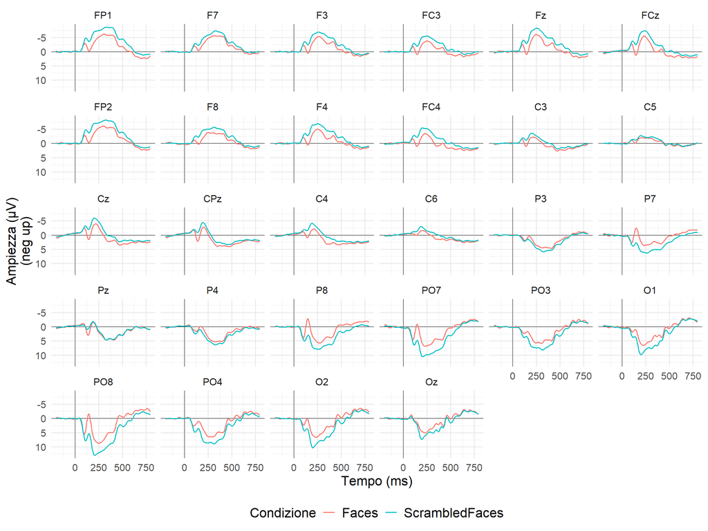

```
# A tibble: 28 × 4
   channel p_value   p_adj significance
   <fct>     <dbl>   <dbl> <chr>
 1 FP1     0.00731 0.00731 **
 2 F7      0.00731 0.00731 **
 3 F3      0.00731 0.00731 **
 4 FC3     0.00731 0.00731 **
 5 Fz      0.00731 0.00731 **
 6 FCz     0.00731 0.00731 **
 7 FP2     0.00731 0.00731 **
 8 F8      0.00731 0.00731 **
 9 F4      0.00731 0.00731 **
10 FC4     0.00731 0.00731 **
# ℹ 18 more rows
```

Osservando la Figura 1 e i risultati del test t per campioni appaiati, si può notare che le differenze tra le condizioni Faces e ScrambledFaces sono altamente significative per tutti gli elettrodi analizzati, il che dimostra che i soggetti elaborano in modo distinto le facce e le facce scambled.. Si è applicato al test t la correzione False Discovery Rate per gestire il problema dei confronti multipli, confermando che le differenze osservate non siano dovute a fluttuazioni casuali.

Qui sotto ho fatto il grafico per il lobo frontale sinistro, avevo visto che nelle prime versioni di codice Davide le aveva fatte, quindi ho sistemato i grafici per renderli come quello sopra, ma ho aggiunto le bande di confidenza. Ditemi voi se tenerli o no.

**Figura 2** ERP (*Event-related potentials*) per *Faces* e *ScrambledFaces* in un compito visivo con gli elettrodi del lobo frontale sinistro. Si noti che il positivo è visualizzato in basso sull’asse y, una convenzione comune nella ricerca ERP.

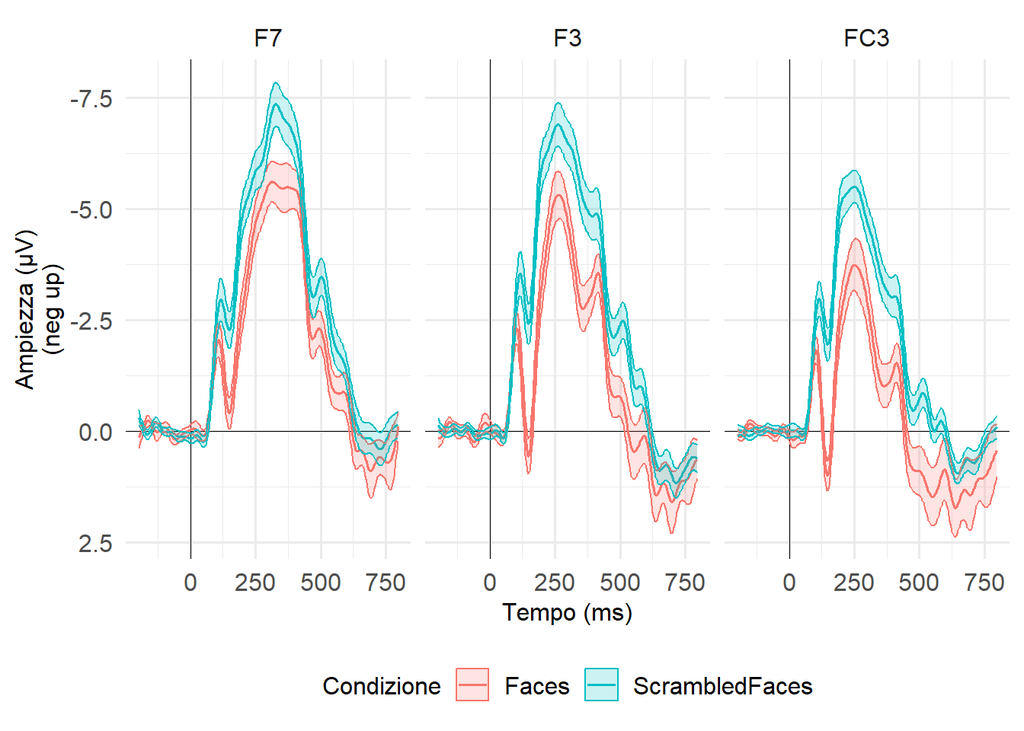

## 2.2 Riportare le statistiche descrittive per le due condizioni sperimentali nella finestra 150-190 ms (per tutti gli elettrodi)

**Figura 3** waveform ERP per le condizioni Faces e ScrambledFaces filtrate per la finestra temporale compresa tra i 150 e i 190 ms.

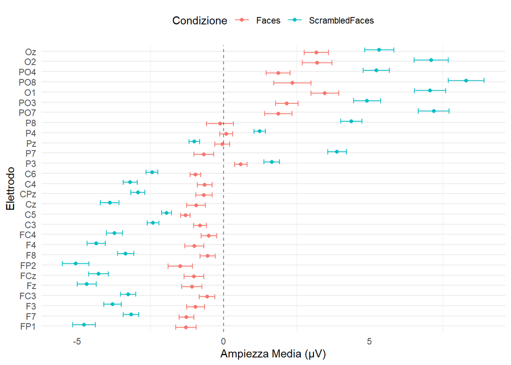